# Comparing ability

In this chapter the $D$-score distributions per GCDG cohort are displayed and the impact of measurement error is compared between the cohorts. Additionally the coverage of the developmental domains is displayed for $D$-score scale and for a single $D$-score.

- D-score distribution by study (@ref(sec:dscores))
- Impact of measurement error (@ref(sec:sem))
- Domain coverage and scores (@ref(sec:domains))

## D-score distribution by study

For each study that is included in the GCDG assembly, the $D$-score can be obtained using the developed global model. In the graphs below, the $D$-score distributions are displayed for each cohort separately. The blue lines in the graphs are the (temporary) references, as explained in @ref(sec:references). By using the `next` button below the plot you can click through the cohorts. Using the selection bar above the graph, you can select a specific cohort.

[interactive chart not shown]

(ref:dscoredist) $D$-score distributions by study.

## Impact of measurement error

For each estimated $D$-score from the calibrated model, the precision of the estimate can be determined. This precision can be expressed as the standard error of measurement ($sem$). The standard error of measurement is inversely related to the number of items. Thus, when more items are administered for a person, the measurement error for the $D$-score of this person will be smaller. As is shown in Figure @ref(fig:semforn), the sem drops fast when the number of items is increased to 15, and still some more until the number of items is 30. More than 30 items has little effect on the sem.

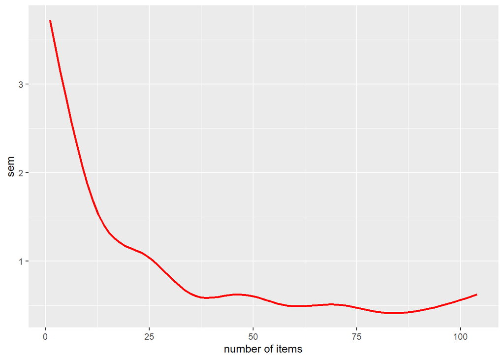

(ref:semforn)

(ref:semforn) Standard error of measurement when the number of items increases.

The precision of the $D$-score estimate is also affected by the information in the items that are administered. This is partly the number of items, as depicted in @ref(fig:semforn), but also if the items are informative for the $D$-score. For example, if the items are too easy and the probability to pass the item given the $D$-score is $P$ > 0.90, the $sem$ is larger than when the difficulty of the administered items is closer to the $D$-score (i.e. $P$ = 0.50). The $sem$ for age in GCDG data (see Figure @ref(fig:semfora)) shows that for some ages, the $sem$ is larger than for others. This is on the one hand due to the number of items available in that age range, but also to the design of the cohorts where sometimes relatively easy items are administered.

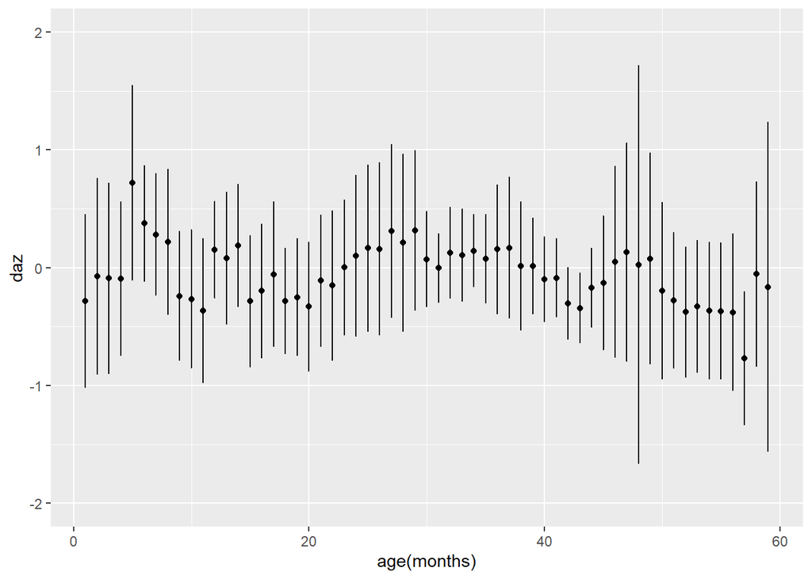

(ref:semfora)

(ref:semfora) Standard error of measurement in each age group.

In Figure @ref(fig:dscoresems), the $sem$ per age group is shown for each cohort separately. This illustrates the differences in design between the cohorts. For example, the Netherlands 1 cohort (GCDG-NLD-SMOCC), the `ddi` was used as a screener and items had the probability to pass of approximately $P$=0.80 (quartile range between 0.62 < $P$ > 1.00), and the number of items administered per measurement is about 10 items (quartile range 6 to 12 items). The Colombia 1 cohort (GCDG-COL-LT45M) was an impact evaluation and has administered the `by3` where each child answered on average 45 items (quartile range 38 to 57 items) and the probability to pass was approximately $P$ = 0.64 (quartile range between 0.53 < $P$ > 0.79). The latter study has therefore more precise $D$-score estimates.

[interactive chart not shown]

(ref:dscoresems)

(ref:dscoresems) The standard error of measurement around the standardized $D$-scores (DAZ) per cohort

The $sem$ for an entire cohort or sample can be obtained by pooling the individual $sem_i$ using general rule for pooling variances. Accordingly, the $sem$ for a sample is obtained by combining the within variance $\sum{sem_{i}^2}$ and the between variance $\sigma_d$ as in equation @ref(eq:poolsem)

$$\begin{equation}
sem = \sqrt{\frac{\sum{sem_{i}^2} + \sigma_d }{N-1}} (\#eq:poolsem)
\end{equation}$$

In Figure @ref(fig:cohortsem) the sample $sem$ per cohort is displayed. The lowest sample $sem$ is found in the Ethiopia study (GCDG-ETH) and the highest in the South Africa cohort (GCDG-ZAF). This can be explained on the one hand by the number of items per child, and on the other hand the difficulty of the administered items.

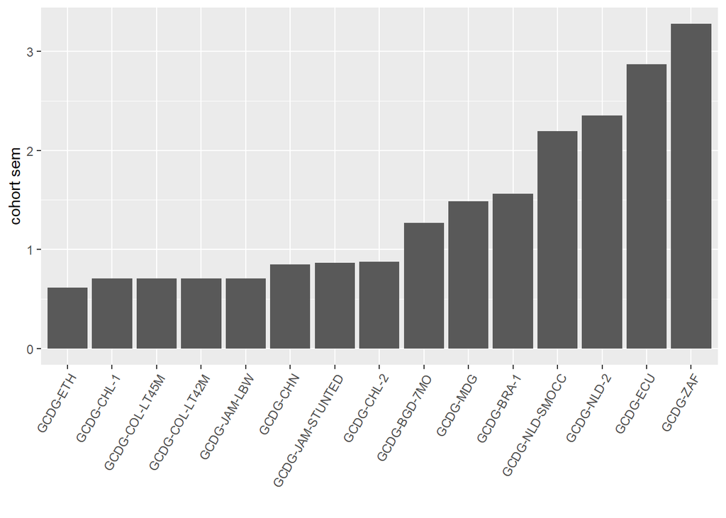

(ref:cohortsem)

(ref:cohortsem) Standard Error of Measurement per cohort.

Table @ref(tab:npsem) shows the median number of items per child (test length) and the probability to pass the items (p). In The Ethiopia cohort 39 items were administered with a median probability of 0.66 and in the South Africa study just 12 items with a median probability of 1. Accordingly, in the Ethiopia study more items were administered per child that also have a high level of information for the $D$-scores. In the South Africa study only few items were administered per child that were also relatively easy and therefore contained less information for the $D$-scores.

Test length and probability to pass the items per cohort

| cohort | test length (median) | pass probability (median) |
| --- | --- | --- |
| GCDG-ETH | 39 | 0.66 |
| GCDG-CHL-1 | 32 | 0.67 |
| GCDG-COL-LT45M | 45 | 0.64 |
| GCDG-COL-LT42M | 61 | 0.62 |
| GCDG-JAM-LBW | 43 | 0.55 |
| GCDG-CHN | 27 | 0.50 |
| GCDG-JAM-STUNTED | 38 | 0.65 |
| GCDG-CHL-2 | 33 | 0.48 |
| GCDG-BGD-7MO | 14 | 0.38 |
| GCDG-MDG | 8 | 0.35 |
| GCDG-BRA-1 | 18 | 0.89 |
| GCDG-NLD-SMOCC | 10 | 0.80 |
| GCDG-NLD-2 | 11 | 1.00 |
| GCDG-ECU | 3 | 0.67 |
| GCDG-ZAF | 12 | 1.00 |

## Domain coverage and scores

The $D$-score is a one number score that measures early child development. To evaluate the content validity of the $D$-score we can make sure that all developmental domains are fairly represented. We distinguish five domains for child development: Fine Motor, Gross Motor, Expressive, Receptive, Cognitive.

### Domain coverage of the scale

The items in the $D$-score model can be linked to one or more domains and the cumulative item information to the $D$-score for each domain can be evaluated. In Figure @ref(fig:domaincov), the coverage of the domains for the $D$-score is displayed. This shows that at lower levels of the $D$-score, gross motor development is more dominant and that at higher levels of the $D$-score the cognitive and language domains increase in importance.

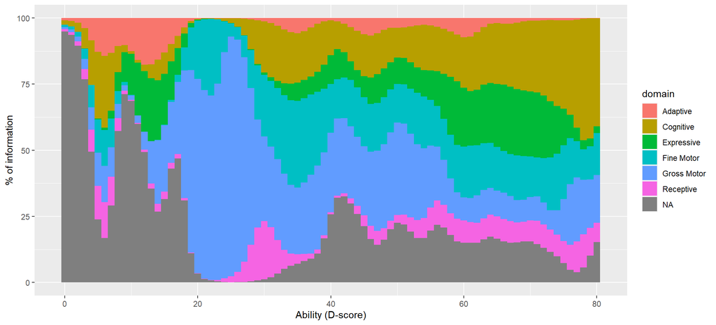

(ref:domaincov)

(ref:domaincov) Domain coverage of the $D$-score scale.

### Domain $D$-scores

It is possible to calculate a $D$-score that is more representative for a specific domain using the current $D$-score model. We can use only the items that load to the domain in question to calculate the $D$-score for that specific domain. Since items may relate to multiple domain, an item can contribute to the $D$-score for multiple domains. As the $D$-score methodology is developed to measure a single construct for development, the domain $D$-scores correlate highly ($r > 0.95$). However, these scores can potentially inform on the cohort level (Figure @ref(fig:domaind)) or the individual level (see Figure @ref(fig:domaindex)).

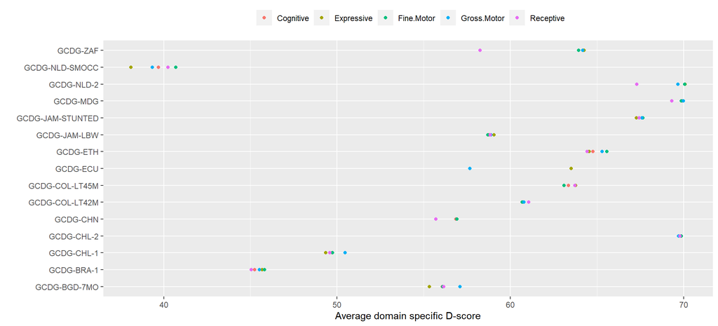

(ref:domaind)

(ref:domaind) Domain $D$-scores per cohort.

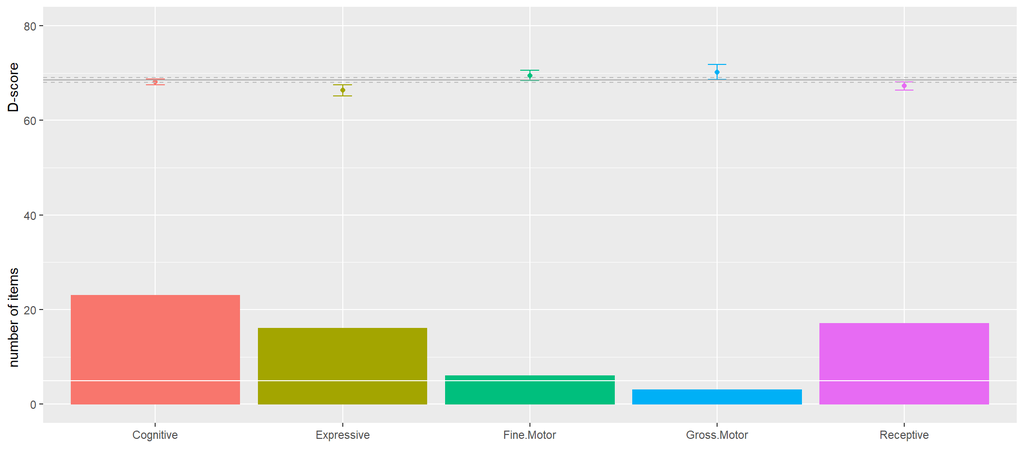

(ref:domaindex)

(ref:domaindex) Domain $D$-scores for a 3 year old boy from the Chile 2 cohort.